# Risk Factor Analysis

## Outcome Variable

**Outcome Variable:** haz

## Predictor Variables

**Intervention Variable:** nchldlt5

**Adjustment Set:**

unadjusted

## Stratifying Variables

The analysis was stratified on these variable(s):

- agecat
- studyid
- country

## Data Summary

| agecat | studyid | country | nchldlt5 | n_cell | n |
| --- | --- | --- | --- | --- | --- |
| Birth | ki1000108-IRC | INDIA | 1 | 84 | 274 |
| Birth | ki1000108-IRC | INDIA | 2+ | 190 | 274 |
| Birth | ki1017093c-NIH-Crypto | BANGLADESH | 1 | 18 | 19 |
| Birth | ki1017093c-NIH-Crypto | BANGLADESH | 2+ | 1 | 19 |
| Birth | kiGH5241-JiVitA-3 | BANGLADESH | 1 | 12104 | 12571 |
| Birth | kiGH5241-JiVitA-3 | BANGLADESH | 2+ | 467 | 12571 |
| 6 months | ki1000108-IRC | INDIA | 1 | 89 | 288 |
| 6 months | ki1000108-IRC | INDIA | 2+ | 199 | 288 |
| 6 months | ki1017093b-PROVIDE | BANGLADESH | 1 | 426 | 435 |
| 6 months | ki1017093b-PROVIDE | BANGLADESH | 2+ | 9 | 435 |
| 6 months | ki1017093c-NIH-Crypto | BANGLADESH | 1 | 507 | 512 |
| 6 months | ki1017093c-NIH-Crypto | BANGLADESH | 2+ | 5 | 512 |
| 6 months | ki1066203-TanzaniaChild2 | TANZANIA, UNITED REPUBLIC OF | 1 | 1391 | 1453 |
| 6 months | ki1066203-TanzaniaChild2 | TANZANIA, UNITED REPUBLIC OF | 2+ | 62 | 1453 |
| 6 months | ki1148112-LCNI-5 | MALAWI | 1 | 390 | 453 |
| 6 months | ki1148112-LCNI-5 | MALAWI | 2+ | 63 | 453 |
| 6 months | kiGH5241-JiVitA-3 | BANGLADESH | 1 | 10887 | 11252 |
| 6 months | kiGH5241-JiVitA-3 | BANGLADESH | 2+ | 365 | 11252 |
| 24 months | ki1000108-IRC | INDIA | 1 | 89 | 290 |
| 24 months | ki1000108-IRC | INDIA | 2+ | 201 | 290 |
| 24 months | ki1017093b-PROVIDE | BANGLADESH | 1 | 423 | 431 |
| 24 months | ki1017093b-PROVIDE | BANGLADESH | 2+ | 8 | 431 |
| 24 months | ki1017093c-NIH-Crypto | BANGLADESH | 1 | 357 | 361 |
| 24 months | ki1017093c-NIH-Crypto | BANGLADESH | 2+ | 4 | 361 |
| 24 months | ki1066203-TanzaniaChild2 | TANZANIA, UNITED REPUBLIC OF | 1 | 5 | 5 |
| 24 months | ki1066203-TanzaniaChild2 | TANZANIA, UNITED REPUBLIC OF | 2+ | 0 | 5 |
| 24 months | ki1148112-LCNI-5 | MALAWI | 1 | 283 | 327 |
| 24 months | ki1148112-LCNI-5 | MALAWI | 2+ | 44 | 327 |
| 24 months | kiGH5241-JiVitA-3 | BANGLADESH | 1 | 5454 | 5673 |
| 24 months | kiGH5241-JiVitA-3 | BANGLADESH | 2+ | 219 | 5673 |

The following strata were considered:

- agecat: 24 months, studyid: ki1000108-IRC, country: INDIA
- agecat: 24 months, studyid: ki1017093b-PROVIDE, country: BANGLADESH
- agecat: 24 months, studyid: ki1017093c-NIH-Crypto, country: BANGLADESH
- agecat: 24 months, studyid: ki1066203-TanzaniaChild2, country: TANZANIA, UNITED REPUBLIC OF
- agecat: 24 months, studyid: ki1148112-LCNI-5, country: MALAWI
- agecat: 24 months, studyid: kiGH5241-JiVitA-3, country: BANGLADESH
- agecat: 6 months, studyid: ki1000108-IRC, country: INDIA
- agecat: 6 months, studyid: ki1017093b-PROVIDE, country: BANGLADESH
- agecat: 6 months, studyid: ki1017093c-NIH-Crypto, country: BANGLADESH
- agecat: 6 months, studyid: ki1066203-TanzaniaChild2, country: TANZANIA, UNITED REPUBLIC OF
- agecat: 6 months, studyid: ki1148112-LCNI-5, country: MALAWI
- agecat: 6 months, studyid: kiGH5241-JiVitA-3, country: BANGLADESH
- agecat: Birth, studyid: ki1000108-IRC, country: INDIA
- agecat: Birth, studyid: ki1017093c-NIH-Crypto, country: BANGLADESH
- agecat: Birth, studyid: kiGH5241-JiVitA-3, country: BANGLADESH

### Dropped Strata

Some strata were dropped due to rare outcomes:

- agecat: Birth, studyid: ki1017093c-NIH-Crypto, country: BANGLADESH
- agecat: 24 months, studyid: ki1017093c-NIH-Crypto, country: BANGLADESH
- agecat: 24 months, studyid: ki1066203-TanzaniaChild2, country: TANZANIA, UNITED REPUBLIC OF

## Methods Detail

We’re interested in the causal parameters $E[Y_a]$ for all values of $a \in \mathcal{A}$. These parameters represent the mean outcome if, possibly contrary to fact, we intervened to set all units to have $A=a$. Under the randomization and positivity assumptions, these are identified by the statistical parameters $\psi_a=E_W[E_{Y|A,W}(Y|A=a,W)]$. In addition, we’re interested in the mean of $Y$, $E[Y]$ under no intervention (the observed mean). We will estimate these parameters by using SuperLearner to fit the relevant likelihood factors – $E_{Y|A,W}(Y|A=a,W)$ and $p(A=a|W)$, and then updating our likelihood fit using a joint TMLE.

For unadjusted analyses ($W=\{\}$), initial likelihoods were estimated using Lrnr_glm to estimate the simple $E(Y|A)$ and Lrnr_mean to estimate $p(A)$. For adjusted analyses, a small library containing Lrnr_glmnet, Lrnr_xgboost, and Lrnr_mean was used.

Having estimated these parameters, we will then use the delta method to estimate relative risks and attributable risks relative to a prespecified baseline level of $A$.

# Results Detail

## Results Plots

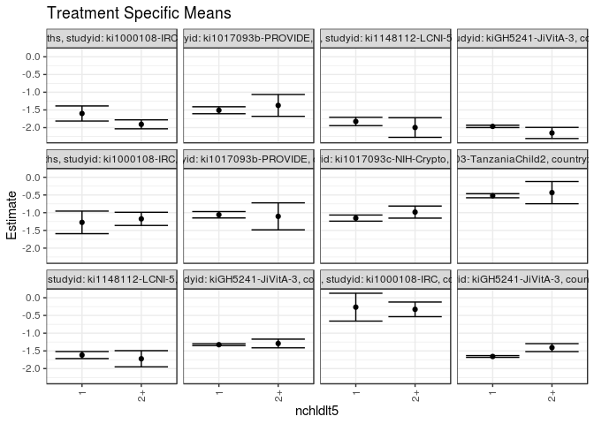

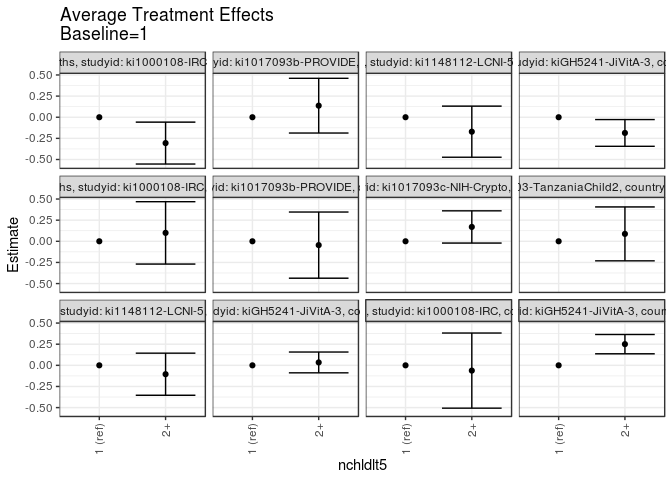

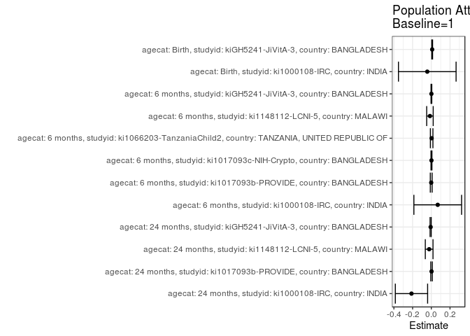

## Results Table

### Parameter: TSM

| agecat | studyid | country | intervention_level | baseline_level | estimate | ci_lower | ci_upper |
| --- | --- | --- | --- | --- | --- | --- | --- |
| Birth | ki1000108-IRC | INDIA | 1 | NA | -0.2657143 | -0.6591005 | 0.1276719 |
| Birth | ki1000108-IRC | INDIA | 2+ | NA | -0.3279474 | -0.5347763 | -0.1211184 |
| Birth | kiGH5241-JiVitA-3 | BANGLADESH | 1 | NA | -1.6584584 | -1.6834117 | -1.6335050 |
| Birth | kiGH5241-JiVitA-3 | BANGLADESH | 2+ | NA | -1.4077730 | -1.5201470 | -1.2953990 |
| 6 months | ki1000108-IRC | INDIA | 1 | NA | -1.2733708 | -1.5921563 | -0.9545853 |
| 6 months | ki1000108-IRC | INDIA | 2+ | NA | -1.1739447 | -1.3599181 | -0.9879713 |
| 6 months | ki1017093b-PROVIDE | BANGLADESH | 1 | NA | -1.0580790 | -1.1483881 | -0.9677700 |
| 6 months | ki1017093b-PROVIDE | BANGLADESH | 2+ | NA | -1.1033333 | -1.4843014 | -0.7223652 |
| 6 months | ki1017093c-NIH-Crypto | BANGLADESH | 1 | NA | -1.1526824 | -1.2389769 | -1.0663880 |
| 6 months | ki1017093c-NIH-Crypto | BANGLADESH | 2+ | NA | -0.9830000 | -1.1531719 | -0.8128281 |
| 6 months | ki1066203-TanzaniaChild2 | TANZANIA, UNITED REPUBLIC OF | 1 | NA | -0.5212527 | -0.5791130 | -0.4633924 |
| 6 months | ki1066203-TanzaniaChild2 | TANZANIA, UNITED REPUBLIC OF | 2+ | NA | -0.4337634 | -0.7472676 | -0.1202593 |
| 6 months | ki1148112-LCNI-5 | MALAWI | 1 | NA | -1.6177692 | -1.7172280 | -1.5183104 |
| 6 months | ki1148112-LCNI-5 | MALAWI | 2+ | NA | -1.7226984 | -1.9510527 | -1.4943441 |
| 6 months | kiGH5241-JiVitA-3 | BANGLADESH | 1 | NA | -1.3257371 | -1.3525722 | -1.2989020 |
| 6 months | kiGH5241-JiVitA-3 | BANGLADESH | 2+ | NA | -1.2914247 | -1.4140205 | -1.1688288 |
| 24 months | ki1000108-IRC | INDIA | 1 | NA | -1.6008801 | -1.8140927 | -1.3876676 |
| 24 months | ki1000108-IRC | INDIA | 2+ | NA | -1.9067828 | -2.0332298 | -1.7803357 |
| 24 months | ki1017093b-PROVIDE | BANGLADESH | 1 | NA | -1.5094090 | -1.6079673 | -1.4108506 |
| 24 months | ki1017093b-PROVIDE | BANGLADESH | 2+ | NA | -1.3725000 | -1.6808079 | -1.0641921 |
| 24 months | ki1148112-LCNI-5 | MALAWI | 1 | NA | -1.8254594 | -1.9433747 | -1.7075440 |
| 24 months | ki1148112-LCNI-5 | MALAWI | 2+ | NA | -1.9965909 | -2.2749947 | -1.7181871 |
| 24 months | kiGH5241-JiVitA-3 | BANGLADESH | 1 | NA | -1.9645911 | -1.9980778 | -1.9311045 |
| 24 months | kiGH5241-JiVitA-3 | BANGLADESH | 2+ | NA | -2.1504110 | -2.3072541 | -1.9935678 |

### Parameter: E(Y)

| agecat | studyid | country | intervention_level | baseline_level | estimate | ci_lower | ci_upper |
| --- | --- | --- | --- | --- | --- | --- | --- |
| Birth | ki1000108-IRC | INDIA | NA | NA | -0.3088686 | -0.4962872 | -0.1214501 |
| Birth | kiGH5241-JiVitA-3 | BANGLADESH | NA | NA | -1.6491457 | -1.6736931 | -1.6245982 |
| 6 months | ki1000108-IRC | INDIA | NA | NA | -1.2046701 | -1.3666765 | -1.0426638 |
| 6 months | ki1017093b-PROVIDE | BANGLADESH | NA | NA | -1.0590153 | -1.1475823 | -0.9704483 |
| 6 months | ki1017093c-NIH-Crypto | BANGLADESH | NA | NA | -1.1510254 | -1.2352824 | -1.0667684 |
| 6 months | ki1066203-TanzaniaChild2 | TANZANIA, UNITED REPUBLIC OF | NA | NA | -0.5175195 | -0.5745106 | -0.4605284 |
| 6 months | ki1148112-LCNI-5 | MALAWI | NA | NA | -1.6323620 | -1.7237497 | -1.5409743 |
| 6 months | kiGH5241-JiVitA-3 | BANGLADESH | NA | NA | -1.3246241 | -1.3512538 | -1.2979943 |
| 24 months | ki1000108-IRC | INDIA | NA | NA | -1.8129023 | -1.9234787 | -1.7023259 |
| 24 months | ki1017093b-PROVIDE | BANGLADESH | NA | NA | -1.5068677 | -1.6032866 | -1.4104489 |
| 24 months | ki1148112-LCNI-5 | MALAWI | NA | NA | -1.8484862 | -1.9573785 | -1.7395940 |
| 24 months | kiGH5241-JiVitA-3 | BANGLADESH | NA | NA | -1.9717645 | -2.0050051 | -1.9385239 |

### Parameter: ATE

| agecat | studyid | country | intervention_level | baseline_level | estimate | ci_lower | ci_upper |
| --- | --- | --- | --- | --- | --- | --- | --- |
| Birth | ki1000108-IRC | INDIA | 1 | 1 | 0.0000000 | 0.0000000 | 0.0000000 |
| Birth | ki1000108-IRC | INDIA | 2+ | 1 | -0.0622331 | -0.5066776 | 0.3822114 |
| Birth | kiGH5241-JiVitA-3 | BANGLADESH | 1 | 1 | 0.0000000 | 0.0000000 | 0.0000000 |
| Birth | kiGH5241-JiVitA-3 | BANGLADESH | 2+ | 1 | 0.2506853 | 0.1365373 | 0.3648333 |
| 6 months | ki1000108-IRC | INDIA | 1 | 1 | 0.0000000 | 0.0000000 | 0.0000000 |
| 6 months | ki1000108-IRC | INDIA | 2+ | 1 | 0.0994261 | -0.2696407 | 0.4684929 |
| 6 months | ki1017093b-PROVIDE | BANGLADESH | 1 | 1 | 0.0000000 | 0.0000000 | 0.0000000 |
| 6 months | ki1017093b-PROVIDE | BANGLADESH | 2+ | 1 | -0.0452543 | -0.4367801 | 0.3462715 |
| 6 months | ki1017093c-NIH-Crypto | BANGLADESH | 1 | 1 | 0.0000000 | 0.0000000 | 0.0000000 |
| 6 months | ki1017093c-NIH-Crypto | BANGLADESH | 2+ | 1 | 0.1696824 | -0.0211190 | 0.3604839 |
| 6 months | ki1066203-TanzaniaChild2 | TANZANIA, UNITED REPUBLIC OF | 1 | 1 | 0.0000000 | 0.0000000 | 0.0000000 |
| 6 months | ki1066203-TanzaniaChild2 | TANZANIA, UNITED REPUBLIC OF | 2+ | 1 | 0.0874893 | -0.2313096 | 0.4062881 |
| 6 months | ki1148112-LCNI-5 | MALAWI | 1 | 1 | 0.0000000 | 0.0000000 | 0.0000000 |
| 6 months | ki1148112-LCNI-5 | MALAWI | 2+ | 1 | -0.1049292 | -0.3540029 | 0.1441446 |
| 6 months | kiGH5241-JiVitA-3 | BANGLADESH | 1 | 1 | 0.0000000 | 0.0000000 | 0.0000000 |
| 6 months | kiGH5241-JiVitA-3 | BANGLADESH | 2+ | 1 | 0.0343125 | -0.0886798 | 0.1573047 |
| 24 months | ki1000108-IRC | INDIA | 1 | 1 | 0.0000000 | 0.0000000 | 0.0000000 |
| 24 months | ki1000108-IRC | INDIA | 2+ | 1 | -0.3059026 | -0.5537906 | -0.0580147 |
| 24 months | ki1017093b-PROVIDE | BANGLADESH | 1 | 1 | 0.0000000 | 0.0000000 | 0.0000000 |
| 24 months | ki1017093b-PROVIDE | BANGLADESH | 2+ | 1 | 0.1369090 | -0.1867691 | 0.4605871 |
| 24 months | ki1148112-LCNI-5 | MALAWI | 1 | 1 | 0.0000000 | 0.0000000 | 0.0000000 |
| 24 months | ki1148112-LCNI-5 | MALAWI | 2+ | 1 | -0.1711315 | -0.4734769 | 0.1312138 |
| 24 months | kiGH5241-JiVitA-3 | BANGLADESH | 1 | 1 | 0.0000000 | 0.0000000 | 0.0000000 |
| 24 months | kiGH5241-JiVitA-3 | BANGLADESH | 2+ | 1 | -0.1858198 | -0.3440712 | -0.0275684 |

### Parameter: PAR

| agecat | studyid | country | intervention_level | baseline_level | estimate | ci_lower | ci_upper |
| --- | --- | --- | --- | --- | --- | --- | --- |
| Birth | ki1000108-IRC | INDIA | 1 | NA | -0.0431543 | -0.3513646 | 0.2650559 |
| Birth | kiGH5241-JiVitA-3 | BANGLADESH | 1 | NA | 0.0093127 | 0.0049392 | 0.0136862 |
| 6 months | ki1000108-IRC | INDIA | 1 | NA | 0.0687006 | -0.1863697 | 0.3237709 |
| 6 months | ki1017093b-PROVIDE | BANGLADESH | 1 | NA | -0.0009363 | -0.0107432 | 0.0088706 |
| 6 months | ki1017093c-NIH-Crypto | BANGLADESH | 1 | NA | 0.0016571 | -0.0033276 | 0.0066417 |
| 6 months | ki1066203-TanzaniaChild2 | TANZANIA, UNITED REPUBLIC OF | 1 | NA | 0.0037332 | -0.0099004 | 0.0173668 |
| 6 months | ki1148112-LCNI-5 | MALAWI | 1 | NA | -0.0145928 | -0.0493935 | 0.0202079 |
| 6 months | kiGH5241-JiVitA-3 | BANGLADESH | 1 | NA | 0.0011131 | -0.0028856 | 0.0051117 |
| 24 months | ki1000108-IRC | INDIA | 1 | NA | -0.2120221 | -0.3846024 | -0.0394419 |
| 24 months | ki1017093b-PROVIDE | BANGLADESH | 1 | NA | 0.0025412 | -0.0057371 | 0.0108195 |
| 24 months | ki1148112-LCNI-5 | MALAWI | 1 | NA | -0.0230269 | -0.0642004 | 0.0181466 |
| 24 months | kiGH5241-JiVitA-3 | BANGLADESH | 1 | NA | -0.0071734 | -0.0132929 | -0.0010539 |